# CSCI_E_106 Section 2

Rafael GT

9/17/2020

## Before you start:

*Create a sub-directory in your computer* Open CANVAS and look for the data *Read specs see below-rephrase the problem with your own words* Master story telling and enjoy the process

# Review from Class 1:

1. Toluca Example (5 minutes)

The Toluca company manufactures refrigerator equipment and parts in lots of various sizes.

Company officials want the size of the lots to be optimized subjet to their production cost.

The key driver of costs is the number of labor hours to produce the lots.

Management collects data on the size of 25 lots and corresponding hours.

Managers believe the information behaves like normal.

Step 1.- State the equation for the normal error model for the problem. Assumptions:
$$Y_i=\beta_o+\beta_iX_i+\varepsilon_i$$

Step3.- Upload Toluca Data to R Studio Cloud:

```r
toluca_data <- read_csv("toluca_data.csv")
head(toluca_data)
```

```
## # A tibble: 6 x 2
##   lotsize workhrs
##     <dbl>   <dbl>
## 1      80     399
## 2      30     121
## 3      50     221
## 4      90     376
## 5      70     361
## 6      60     224
```

```r
View(toluca_data)
attach(toluca_data)
```

Step4 fitting the regression model:

```r
toluca.reg <- lm(workhrs ~ lotsize)
```

Step5 getting the summary regression output:

```r
summary(toluca.reg)
```

```
##
## Call:
## lm(formula = workhrs ~ lotsize)
##
## Residuals:
##     Min      1Q  Median      3Q     Max
## -83.876 -34.088  -5.982  38.826 103.528
##
## Coefficients:
##             Estimate Std. Error t value Pr(>|t|)
## (Intercept)   62.366     26.177   2.382   0.0259 *
## lotsize        3.570      0.347  10.290 4.45e-10 ***
## ---
## Signif. codes:  0 '***' 0.001 '**' 0.01 '*' 0.05 '.' 0.1 ' ' 1
##
## Residual standard error: 48.82 on 23 degrees of freedom
## Multiple R-squared:  0.8215, Adjusted R-squared:  0.8138
## F-statistic: 105.9 on 1 and 23 DF,  p-value: 4.449e-10
```

Step6 getting the Analysis of Variance table (ANOVA):

```r
anova(toluca.reg)
```

```
## Analysis of Variance Table
##
## Response: workhrs
##           Df Sum Sq Mean Sq F value    Pr(>F)
## lotsize    1 252378  252378  105.88 4.449e-10 ***
## Residuals 23  54825    2384
## ---
## Signif. codes:  0 '***' 0.001 '**' 0.01 '*' 0.05 '.' 0.1 ' ' 1
```

Step7 getting the fitted values:

```r
fitted(toluca.reg)
```

```
##        1        2        3        4        5        6        7        8
## 347.9820 169.4719 240.8760 383.6840 312.2800 276.5780 490.7901 347.9820
##        9       10       11       12       13       14       15       16
## 419.3861 240.8760 205.1739 312.2800 383.6840 133.7699 455.0881 419.3861
##       17       18       19       20       21       22       23       24
## 169.4719 240.8760 383.6840 455.0881 169.4719 383.6840 205.1739 347.9820
##       25
## 312.2800
```

Step8 getting the residual values (why not the errors?):

```r
names(toluca.reg)
```

```
##  [1] "coefficients"  "residuals"     "effects"       "rank"
##  [5] "fitted.values" "assign"        "qr"            "df.residual"
##  [9] "xlevels"       "call"          "terms"         "model"
```

```r
resid(toluca.reg)
```

```
##           1           2           3           4           5           6
##  51.0179798 -48.4719192 -19.8759596  -7.6840404  48.7200000 -52.5779798
##           7           8           9          10          11          12
##  55.2098990   4.0179798 -66.3860606 -83.8759596 -45.1739394 -60.2800000
##          13          14          15          16          17          18
##   5.3159596 -20.7698990 -20.0880808   0.6139394  42.5280808  27.1240404
##          19          20          21          22          23          24
##  -6.6840404 -34.0880808 103.5280808  84.3159596  38.8260606  -5.9820202
##          25
##  10.7200000
```

```r
toluca.reg$residuals
```

```
##           1           2           3           4           5           6
##  51.0179798 -48.4719192 -19.8759596  -7.6840404  48.7200000 -52.5779798
##           7           8           9          10          11          12
##  55.2098990   4.0179798 -66.3860606 -83.8759596 -45.1739394 -60.2800000
##          13          14          15          16          17          18
##   5.3159596 -20.7698990 -20.0880808   0.6139394  42.5280808  27.1240404
##          19          20          21          22          23          24
##  -6.6840404 -34.0880808 103.5280808  84.3159596  38.8260606  -5.9820202
##          25
##  10.7200000
```

Step9 overlaying the regression line on the scatter plot of X and Y:

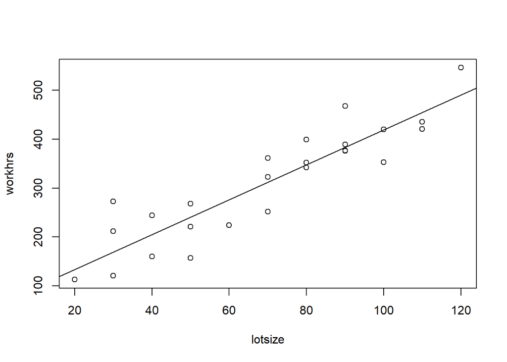

[output not shown]

```r
plot(lotsize, workhrs)
abline(toluca.reg)
```

```r
head(Beerdata)
```

```
## # A tibble: 6 x 8
##    beer   tpc    ma   dsa   asa  orac    rp   mca
##   <dbl> <dbl> <dbl> <dbl> <dbl> <dbl> <dbl> <dbl>
## 1     1  148. 13.4   0.66  0.81  3.81  0.45 10.6
## 2     2  160. 11.0   0.63  0.64  2.85  0.41 15.5
## 3     3  170.  9.22  0.62  0.81  3.34  0.48 15.7
## 4     4  209.  9.65  0.9   1.01  3.34  0.5  76.6
## 5     5  146. 11.7   0.64  0.9   3.18  0.47  9.39
## 6     6  180.  9.33  0.62  1.48  4.33  0.71 23.4
```

```r
View(Beerdata)
attach(Beerdata)
Beerdata=data.frame(Beerdata)
```

Step4.- Fit one variable regression model with TPC as a dependent variable against remaining variables above, as an independent variable one at time For example, TPC = bo + b1 MA, TPC=b0+b1 DSA and so on:

```r
f1<-lm(tpc~ma,data=Beerdata)
f2<-lm(tpc~dsa,data=Beerdata)
f3<-lm(tpc~asa,data=Beerdata)
f4<-lm(tpc~orac,data=Beerdata)
f5<-lm(tpc~rp,data=Beerdata)
f6<-lm(tpc~mca,data=Beerdata)
```

Step5.-Let know the computer how to organize the information. Use an R-function. The “par(mfrow)” function is handy for creating a simple multi-paneled plot:

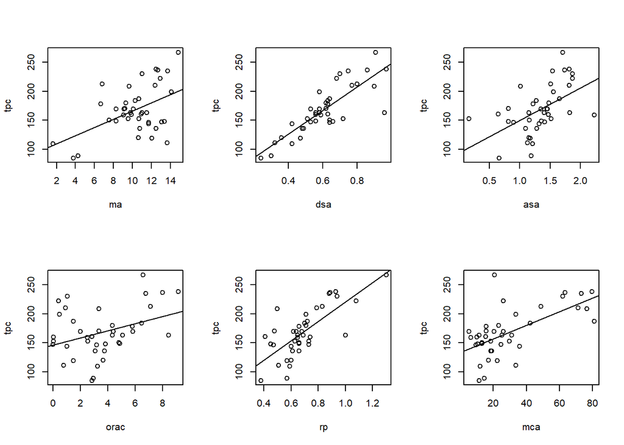

```r
par(mfrow=c(2,3))
plot(ma,tpc);abline(f1)
plot(dsa,tpc);abline(f2)
plot(asa,tpc);abline(f3)
plot(orac,tpc);abline(f4)
plot(rp,tpc);abline(f5)
plot(mca,tpc);abline(f6)
```

Step6.-Use an R-function to find the best fit. Each function needs to input the parameters “function(here the variables)”, to know where the results are going to be saved (“data.framework”), when to stop (for i…). What is the equation or operations you want to do:

```r
prg1<-function(x){
  out1<-list({})
  out2<-data.frame(matrix(0,nrow=6,ncol=2))

           for (i in 1:6){

                    out1[[i]]<-lm(x[,2]~x[,2+i],data=x)

                    out2[i,]<-cbind(dimnames(x)[[2]][2+i],round(sum(out1[[i]]$residuals^2),2))

                              }
   dimnames(out2)[[2]]<-c("X","SSE")

   list(out1,out2)
}
prg1(Beerdata)
```

```
## [[1]]
## [[1]][[1]]
##
## Call:
## lm(formula = x[, 2] ~ x[, 2 + i], data = x)
##
## Coefficients:
## (Intercept)   x[, 2 + i]
##      95.405        7.069
##
##
## [[1]][[2]]
##
## Call:
## lm(formula = x[, 2] ~ x[, 2 + i], data = x)
##
## Coefficients:
## (Intercept)   x[, 2 + i]
##       44.86       202.75
##
##
## [[1]][[3]]
##
## Call:
## lm(formula = x[, 2] ~ x[, 2 + i], data = x)
##
## Coefficients:
## (Intercept)   x[, 2 + i]
##       93.68        55.84
##
##
## [[1]][[4]]
##
## Call:
## lm(formula = x[, 2] ~ x[, 2 + i], data = x)
##
## Coefficients:
## (Intercept)   x[, 2 + i]
##     146.320        6.136
##
```

[output cut: 15 more lines]

```
##
## Coefficients:
## (Intercept)   x[, 2 + i]
##     133.491        1.169
##
##
##
## [[2]]
##      X      SSE
## 1   ma 52272.15
## 2  dsa 20930.66
## 3  asa 48685.94
## 4 orac 59252.34
## 5   rp 30783.35
## 6  mca 41677.52
```